# Regression Analysis and Qualitative Regressors

# Review Dataframes and Data Manipulation

R has many “packages”, essentially add-ons to the basic R program that allow you to implement new techniques or access new methods. One absolutely essential add-on is called `tidyverse`, which provides a set of methods for manipulating data and visualizing it.

This package includes among others the package `dplyr` that we will use for data manipulation.

## Review `dplyr` package and it’s functions

The use of the package dplyr relies the pipe symbol `%>%`. This expression roughly translates to “and then”. You use it before every function of this packages in your code to makes things more efficient and not repeat the name of your dataframe every time. Below is a description of the dplyr functions.

| function | Purpose |
| --- | --- |
| filter() | Select rows based on criteria |
| arrange() | order rows |
| select() | choose columns |
| distinct() | unique values of column(s) |
| mutate() and transmute() | Create new columns |
| summarise() | Find a summary statistic |
| sample_n() | Take a random sample |
| group_by() | Creates groups based on the values or categories of a variable. |

We will be using this package most of the time when finding descriptive statistics for our data before doing a regression analysis.

# Descriptive statistics tables

## table(), prop.table()

We use the factors function that you will learn next week in Datacamp to generate meaning labels to our tables.

```r
data(affairs, package='wooldridge')
str(affairs) # provides information about the structure of the data set
```

```
## 'data.frame':    601 obs. of  19 variables:
##  $ id      : int  4 5 6 11 12 16 23 29 43 44 ...
##  $ male    : int  1 0 1 0 0 1 1 0 1 0 ...
##  $ age     : num  37 27 27 32 27 57 22 32 37 22 ...
##  $ yrsmarr : num  10 4 1.5 15 4 15 0.75 1.5 15 0.75 ...
##  $ kids    : int  0 0 0 1 1 1 0 0 1 0 ...
##  $ relig   : int  3 4 3 1 3 5 2 2 5 2 ...
##  $ educ    : int  18 14 18 12 17 18 17 17 18 12 ...
##  $ occup   : int  7 6 4 1 1 6 6 5 6 1 ...
##  $ ratemarr: int  4 4 4 4 5 5 3 5 2 3 ...
##  $ naffairs: int  0 0 3 0 3 0 0 0 7 0 ...
##  $ affair  : int  0 0 1 0 1 0 0 0 1 0 ...
##  $ vryhap  : int  0 0 0 0 1 1 0 1 0 0 ...
##  $ hapavg  : int  1 1 1 1 0 0 0 0 0 0 ...
##  $ avgmarr : int  0 0 0 0 0 0 1 0 0 1 ...
##  $ unhap   : int  0 0 0 0 0 0 0 0 1 0 ...
##  $ vryrel  : int  0 0 0 0 0 1 0 0 1 0 ...
##  $ smerel  : int  0 1 0 0 0 0 0 0 0 0 ...
##  $ slghtrel: int  1 0 1 0 1 0 0 0 0 0 ...
##  $ notrel  : int  0 0 0 0 0 0 1 1 0 1 ...
##  - attr(*, "time.stamp")= chr "25 Jun 2011 23:03"
```

```r
# Generate "Factors" to attach labels
haskids <- factor(affairs$kids,labels=c("no","yes"))
mlab <- c("very unhappy","unhappy","average","happy", "very happy")
marriage <- factor(affairs$ratemarr, labels=mlab)

# Frequencies for having kids:
table(haskids)
```

```
## haskids
##  no yes
## 171 430
```

```r
prop.table(table(affairs$affair))
```

```
##
##        0        1
## 0.750416 0.249584
```

```r
# Marriage ratings (share):
prop.table(table(marriage))
```

```
## marriage
## very unhappy      unhappy      average        happy   very happy
##    0.0266223    0.1098170    0.1547421    0.3227953    0.3860233
```

```r
# Contigency table: counts (display & store in var.)
(countstab <- table(marriage,haskids))
```

```
##               haskids
## marriage        no yes
##   very unhappy   3  13
##   unhappy        8  58
##   average       24  69
##   happy         40 154
##   very happy    96 136
```

```r
prop.table(countstab)
```

```
##               haskids
## marriage                no         yes
##   very unhappy 0.004991681 0.021630616
##   unhappy      0.013311148 0.096505824
##   average      0.039933444 0.114808652
##   happy        0.066555740 0.256239601
##   very happy   0.159733777 0.226289517
```

```r
# Share within "marriage" (i.e. within a row):
kable(prop.table(countstab, margin=1),digits=2)
```

|  | no | yes |
| --- | --- | --- |
| very unhappy | 0.19 | 0.81 |
| unhappy | 0.12 | 0.88 |
| average | 0.26 | 0.74 |
| happy | 0.21 | 0.79 |
| very happy | 0.41 | 0.59 |

```r
# Share within "haskids"  (i.e. within a column):
kable(prop.table(countstab, margin=2), digits=2)
```

|  | no | yes |
| --- | --- | --- |
| very unhappy | 0.02 | 0.03 |
| unhappy | 0.05 | 0.13 |
| average | 0.14 | 0.16 |
| happy | 0.23 | 0.36 |
| very happy | 0.56 | 0.32 |

## Fundamental statistics

```r
# data(ceosal1, package='wooldridge')
# summary information:
summary(ceosal1$salary)
```

```
##    Min. 1st Qu.  Median    Mean 3rd Qu.    Max.
##     223     736    1039    1281    1407   14822
```

```r
# sample average:
mean(ceosal1$salary)
```

```
## [1] 1281.12
```

```r
# sample median:
median(ceosal1$salary)
```

```
## [1] 1039
```

```r
# standard deviation:
sd(ceosal1$salary)
```

```
## [1] 1372.345
```

```r
# correlation with ROE:
cor(ceosal1$salary, ceosal1$roe)
```

```
## [1] 0.1148417
```

You can use the package `dplyr` to find that information in just one line of code.

```r
library(tidyverse) # load the package
#data(ceosal1, package='wooldridge')

(salarystats<-ceosal1 %>% summarise(avgsal=mean(salary), medsal=median(salary), sdsal=sd(salary), corsal_roe=cor(salary, roe)))
```

```
##    avgsal medsal    sdsal corsal_roe
## 1 1281.12   1039 1372.345  0.1148417
```

### Practice

Taken from Wooldridge computer exercise 2 chapter 1.

Use the data in BWGHT to answer this question. the description of this dataset is here

http://fmwww.bc.edu/ec-p/data/wooldridge/bwght.des

- 1. How many women are in the sample, and how many report smoking during pregnancy?
- 2. What is the average number of cigarettes smoked per day?
- 3. Among women who smoked during pregnancy, what is the average number of cigarettes smoked per day?
- 4. Find the average of fatheduc in the sample. Why are only 1,192 observations used to compute this average?
- 22. Report the average family income and its standard deviation in dollars.

```r
# str(bwght)
library(tidyverse)
data(bwght, package='wooldridge')
# Translate the following into R using dplyr

# use dataset bwgth and then use function summarize to calculate the number of women by using the function length on any variable in the data ( I will use the variable male that refers to the gender of the baby) name this women
# in the same summarize name smokepreg the number of women that smoke during pregnancy by adding all the observation for which cigs>0
# calculate average of cigs smoked
# average of education, family income and sd of family income give anmes to these inside the summarize function

(summstat<-bwght %>%
summarize(women=length(male), smokepreg=sum(cigs>0), avgcig=mean(cigs), avgfathereduc=mean(fatheduc, na.rm=T), avgfaminc=mean(faminc), sd(faminc))) # here we are answering most of the questions in one line of code using the %>% symbol from the package dplyr
```

```
##   women smokepreg   avgcig avgfathereduc avgfaminc sd(faminc)
## 1  1388       212 2.087176      13.18624  29.02666   18.73928
```

```r
# Average of cigarettes smoked per day by the women who smoked
bwght%>%filter(cigs>0)%>% summarize(mean(cigs))
```

```
##   mean(cigs)
## 1   13.66509
```

```r
mean(bwght$fatheduc, na.rm = TRUE) # takes the averages and excludes missing values
```

```
## [1] 13.18624
```

```r
length(bwght$fatheduc)-sum(is.na(bwght$fatheduc))# tells you how many observations had values
```

```
## [1] 1192
```

## Correlations

Let’s look back at our CEO salary data ceosal1

- extract the variables roe, salary and sales and calculate the correlations among those, name the object cormat and use parenthesis to print the object.

```r
(cormat <- round(cor(ceosal1[,c('roe','salary', 'sales', 'lsalary', 'lsales')]),2))
```

```
##           roe salary sales lsalary lsales
## roe      1.00   0.11 -0.06    0.21  -0.12
## salary   0.11   1.00  0.12    0.79   0.19
## sales   -0.06   0.12  1.00    0.28   0.74
## lsalary  0.21   0.79  0.28    1.00   0.46
## lsales  -0.12   0.19  0.74    0.46   1.00
```

Let’s look at the correlation plots (More on this next class)

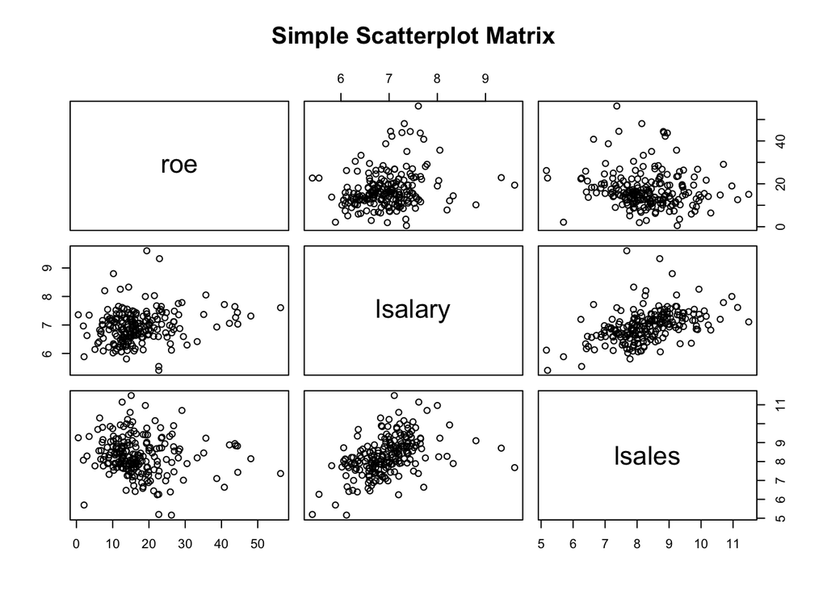

```r
# Correlation matrix graph
pairs(~roe+lsalary+lsales,data=ceosal1,
   main="Simple Scatterplot Matrix")
```

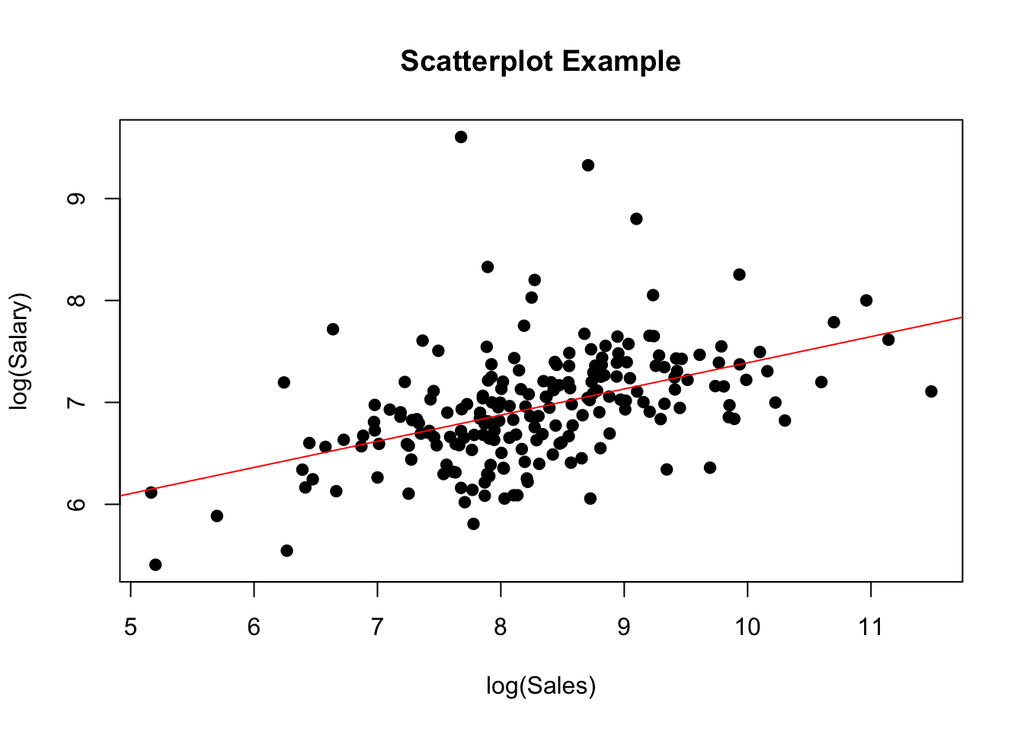

```
## integer(0)
```

```r
#Basic scatter plot and regression line
plot(ceosal1$lsales , ceosal1$lsalary, main="Scatterplot Example",
   xlab="log(Sales)", ylab="log(Salary)", pch=19)+ abline(lm(ceosal1$lsalary~ceosal1$lsales), col="red")
```

[figure not shown]

```r
# Scatther plot using ggplot
ggplot(ceosal1, aes(lsalary, lsales))+
  geom_point(color="red") +
  geom_smooth(method='lm')+ ggtitle('log(Salary) vs log(Sales)') +
  xlab('log(Sales)') +
  ylab('log(Salary)')
```

# Wooldridge Chapter 1 exercises

## C1

```r
# str(wage1) run this to see the variables you have or check the description on the web
# Find the average education level in the sample. What are the lowest and highest years of education?
# Find the average hourly wage in the sample.
#   How many women are in the sample? How many men?

wage1 %>%
summarise (mean(educ), min(educ), max(educ), average_wage=mean(wage), women=sum(female), men=sum(female==0)) %>%
  gather(variables,values)
```

```
##      variables     values
## 1   mean(educ)  12.562738
## 2    min(educ)   0.000000
## 3    max(educ)  18.000000
## 4 average_wage   5.896103
## 5        women 252.000000
## 6          men 274.000000
```

```r
#find CPI
# CPI-1982 100 # CPI-1976 = 56.9 & CPI_2013= 233.0
CPIratio76_13<-233/56.9
wage13=wage1$wage*CPIratio76_13
mean(wage13)
```

```
## [1] 24.14397
```

## C3

```r
# str(meap01)
# The next line of code translates into  take the dataset meap01 and then select the variables math4 read4 exppp and then use the function summarize to calculate the mean min and max of those variables making sure to eliminate the missing values to be able to claculate those stats that is done by using na.rm=TRUE
meap01%>%select(math4, read4, exppp)%>% summarise_all(list(mean, min, max),  na.rm = TRUE)
```

```
##   math4_fn1 read4_fn1 exppp_fn1 math4_fn2 read4_fn2 exppp_fn2 math4_fn3
## 1    71.909  60.06188  5194.865         0         0  1206.882       100
##   read4_fn3 exppp_fn3
## 1       100  11957.64
```

```r
summary(meap01$math4) # makes a summary of the variable math4
```

```
##    Min. 1st Qu.  Median    Mean 3rd Qu.    Max.
##    0.00   61.60   76.40   71.91   87.00  100.00
```

```r
summary(meap01$read4) # makes a summary of the variable read4
```

```
##    Min. 1st Qu.  Median    Mean 3rd Qu.    Max.
##    0.00   48.90   62.70   60.06   73.90  100.00
```

```r
sd(meap01$exppp) # calculates the sd of variable
```

```
## [1] 1091.89
```

```r
sum(meap01$math4==100)
```

```
## [1] 38
```

```r
(mathpassrates_50=sum(meap01$math4==50)) #
```

```
## [1] 17
```

```r
cor(meap01$math4 , meap01$read4)
```

```
## [1] 0.8427281
```

**Packages used in this document**

`library(wooldridge)`

`library(tidyverse)`

`library(knitr)`

ECON220 R Programing Laboratory

Professor *Paloma Lopez de mesa Moyano*

*paloma.moyano@emory.edu*

Department of Economics

Emory University